# Exame de MOQ-13: PARTE 1

Problema 01 (5,0 pts)

Aluno: Bruno Lima Queiroz Santos

Turma T22.3

Professora: Denise B. Ferrari

Data: 22/11/2019

## Instruções:

1. As respostas serão avaliadas com relação à:
1. reprodutibilidade;
2. correção; e
3. completude da solução proposta, devendo incluir:

```
+ Enunciado do problema
+ Apresentação da estratégia de solução
+ Resultados (resumos numéricos e gráficos)
+ Análise dos resultados obtidos
+ Código R comentado
+ Referências (textos, sites etc.)
```

**OBS:**  
Existe um volume enorme de código disponível na internet para resolver praticamente qualquer problema. O reuso de código obtido online é permitido, desde que citada a fonte (mesmo que tenha sido utilizada apenas como inspiração…)

**Prazo: 06/12/2019**

**Entregáveis:**

- Todos os arquivos utilizados para realizar a tarefa, organizados em uma pasta, seguindo o modelo:

```
[Turma-22-X]_[Nome-Aluno]_Exame-P1
  |-data
  |-img
  |-[Turma-22-X]_[Nome-Aluno]_Exame-P1.html
  |-[Turma-22-X]_[Nome-Aluno]_Exame-P1.Rmd
```

- Submeter todo o material em uma pasta via **CLASSROOM**.

## Introdução

Em um pronto-atendimento oftalmológico há 2 consultórios médicos. A clínica abre às 9h e os pacientes chegam de acordo com um processo de Poisson com taxa 10min, ou seja, este é o tempo esperado de chegada do primeiro cliente após a abertura da clínica. Os pacientes podem ser atendidos indiscriminadamente por qualquer um dos plantonistas. Ao chegar na clínica, o paciente aguarda até que um dos médicos esteja disponível. A duração de cada consulta é uma variável aleatória uniformemente distribuída entre 5 e 20 minutos. A clínica deixa de admitir novos pacientes às 16h e fecha após terminado o atendimento do último paciente.

## PARTE 1: Estratégia de Solução Computacional

> Apresente a estratégia adotada para solução computacional.

A estratégia geral consiste em gerar uma contagem para a variável $N(t)$, que denota o número de clientes que chegam ao pronto-atendimento num intervalo de tempo de comprimento $\Delta t= t$ seguindo o processo de Poisson, para cada um dos $\frac{(16-9)horas}{t }\cdot\frac{k \;[\; dimensão\; da \; variável \;\; t\;]}{1 \;\;hora}$ intervalos, onde $k$ é o fator de conversão entre as dimensões de tempo. Seguir-se-á a divisão em intervalos de $t=5$ minutos para obter-se uma boa e leve aproximação a uma contagem contínua no tempo, ou seja, uma contagem a cada instante t para os resultados da simulação. Isso significa que o responsável pela portaria anota a variação da contagem na catraca de entrada a cada 5 minutos desde as 9 horas até as 16 horas. Uma contagem contínua seria o registro dessas variações a todo instante $dt$. Assim, assumir-se-á que todos $N(t=5\;min)$ no $i-$ésimo instante chegam juntos e exatamente ao final do instante. Por exemplo, se para o $5º$ instante $N(t=5)=2$, então, $2$ pessoas chegaram ao pronto atendimento em $9$ horas $+ 5 \cdot 5$ minutos, ou seja, exatamente $2$ pessoas chegam ao pronto atendimento juntas, independente e coincidentemente às $9:25$ exatamente.

Isso será simulado por meio da função `rpois` que gerará os $\frac{7\;horas}{5\;min}\cdot \frac{60\;min}{1\;hora}=84$ intervalos segundo um valor esperado $\lambda t = \frac{1\; pessoa}{10\;min}\cdot 5 \; min$.

Depois disso, haverá uma rotina para estabelecer o instante de chegada para cada cliente segundo uma FILA por ordem de chegada. Então, com algumas funções auxiliares construídas para evitar repetições no código, construir-se-á a rotina que irá construir um vetor indicando o início dos atendimentos individuais gerado considerando um vetor auxiliar de tamanho 2 indicando o final dos atendimentos atuais individuais em cada um dos consultórios para que seja construída uma MATRIZ de duas colunas em que cada linha indica o início de um atendimento individual para o consultório médico referido pela coluna. Também, nessa rotina há a construção da representação em um vetor linha dos horários de início de atendimento segundo a FILA e o tempo de duração de cada consulta gerados pela função `runif` na faixa de tempo de 5 minutos a 20 minutos. E finalmente, é construído um subvetor de 2 colunas indicando o horário de termino dos atendimentos. Todos os subvetores gerados serão repassados pela função permitindo que sejam gerados a MATRIZ, um vetor coluna com os horários de início de atendimento e , a partir daí, o vetor com cada um dos atrasos é gerado pela diferença entre os vetores colunas atendimento e fila.

## PARTE 2: Solução Computacional

> Escreva um programa em R para simular este processo apenas uma vez e responda às seguintes questões:

```r
N<-rpois(84,((1/10)*(5)) )
#N
```

```r
#instant<-c(rep(0,length(N)))
FILA<-c()
for ( i in 1:length(N)){
  if(N[i]>0){
    for(j in 1:N[i]){
      FILA<-c(FILA,5*i)
    }
  }
}
#FILA
T1<-0
T2<-0
#<-function(T,)
```

```r
T1<-0
T2<-0

MENOR<-function(t1,t2){
  if(t1<=t2){
    return(1)
  }
  else{
    return(2)
  }
}

MAIOR<-function(t1,t2){
  if(t1>=t2){
    return(1)
  }
  else{
    return(2)
  }
}


# I = v[k] #INSERIR o maior valor
ATUALIZAR<-function(I,u,dt){
  if(I==0){
    return(u)
  }
  else{
    #dt<-runif(1,5,20)
    V<-c(u,I+dt)
    VR<-MAIOR(V[1],V[2])#OBTENÇÃO DO ÍNDICE DO MAIOR VALOR
    return(V[VR])
  }
}

# I = v[k] #INSERIR o maior valor

SIMULING<-function(f){

  MATRIX<-c()
  v<-c(0,0)
  MATRIX<-c(MATRIX,v)
  time_f<-c(0,0)
  #MATRIZ<-c(0,0)
  #COUNT<-0
  LINEAR<-c()
  for(i in f){
    #k=MENOR(v[1],v[2])#ÍNDICE do menor instante fornecido
    k=MENOR(time_f[1],time_f[2])#ÍNDICE do menor instante fornecido
    dt<-runif(1,5,20)
    v[k]<-ATUALIZAR(v[k],i,dt)#atualizar o instante de início
    time_f[k]<-ATUALIZAR(time_f[k],i,dt)#atualizar o menor instante de encerramento
    MATRIX<-c(MATRIX,v)
    LINEAR<-c(LINEAR,v[k])
    #print(v)
  }
  FINAL<-c(runif(1,5,20),runif(1,5,20))
  FINAL<-FINAL+c(MATRIX[length(MATRIX)-1],MATRIX[length(MATRIX)])
  return(c(LINEAR,MATRIX,FINAL))
}
```

```r
print(FILA)
```

```
##  [1]   5  15  20  40  55  75  85  90 105 110 135 135 155 160 180 180 210
## [18] 215 230 240 245 280 315 340 345 355 360 360 365 375 375 380 385 385
## [35] 400 405
```

```r
cat("                                 \n")
```

```r
cat("#################################\n")
```

```
## #################################
```

```r
cat("                                 \n")
```

```r
A<-SIMULING(FILA)
#MATRIX<-matrix(A[],ncol=2,byrow=TRUE)
#MATRIX
ATENDIMENTO<-A[1:length(FILA)]
ATENDIMENTO<-matrix(ATENDIMENTO,ncol=1,byrow=TRUE)
ATENDIMENTO
```

```
##           [,1]
##  [1,]   5.0000
##  [2,]  15.0000
##  [3,]  20.4256
##  [4,]  40.0000
##  [5,]  55.0000
##  [6,]  75.0000
##  [7,]  85.0000
##  [8,]  90.0000
##  [9,] 105.0000
## [10,] 110.0000
## [11,] 135.0000
## [12,] 135.0000
## [13,] 155.0000
## [14,] 160.0000
```

[output cut: 22 more lines]

```r
fila<-matrix(FILA,nco=1,byrow=TRUE)
fila
```

```
##       [,1]
##  [1,]    5
##  [2,]   15
##  [3,]   20
##  [4,]   40
##  [5,]   55
##  [6,]   75
##  [7,]   85
##  [8,]   90
##  [9,]  105
## [10,]  110
## [11,]  135
## [12,]  135
## [13,]  155
## [14,]  160
```

[output cut: 22 more lines]

```r
ATRASO<-ATENDIMENTO-fila
ATRASO
```

```
##             [,1]
##  [1,]  0.0000000
##  [2,]  0.0000000
##  [3,]  0.4256002
##  [4,]  0.0000000
##  [5,]  0.0000000
##  [6,]  0.0000000
##  [7,]  0.0000000
##  [8,]  0.0000000
##  [9,]  0.0000000
## [10,]  0.0000000
## [11,]  0.0000000
## [12,]  0.0000000
## [13,]  0.0000000
## [14,]  0.0000000
```

[output cut: 22 more lines]

```r
MATRIX<-A[(1+length(FILA)):(length(A)-2)]
FINAL<-A[(length(A)-1):(length(A))]
rm(FILA)
MATRIX<-matrix(MATRIX,ncol=2,byrow=TRUE)
MATRIX
```

```
##           [,1]     [,2]
##  [1,]   0.0000   0.0000
##  [2,]   5.0000   0.0000
##  [3,]   5.0000  15.0000
##  [4,]  20.4256  15.0000
##  [5,]  20.4256  40.0000
##  [6,]  55.0000  40.0000
##  [7,]  55.0000  75.0000
##  [8,]  85.0000  75.0000
##  [9,]  85.0000  90.0000
## [10,] 105.0000  90.0000
## [11,] 105.0000 110.0000
## [12,] 135.0000 110.0000
## [13,] 135.0000 135.0000
## [14,] 155.0000 135.0000
```

[output cut: 23 more lines]

```r
FINAL
```

```
## [1] 435.2281 432.7617
```

```r
rm(A)
```

1. Quantos pacientes vieram até a clínica?

```r
cat(sum(N)," ", "pacientes vieram até a clínica")
```

```
## 36   pacientes vieram até a clínica
```

2. Quantos pacientes tiveram que aguardar para serem atendidos?

```r
ATRASADOS<-ATRASO[ATRASO>0]
ATRASADOS<-length(ATRASADOS)
cat(ATRASADOS,"pacientes tiveram que aguardar para serem atendidos")
```

```
## 13 pacientes tiveram que aguardar para serem atendidos
```

3. Qual o tempo médio de espera?

```r
cat(sum(ATRASO)/ATRASADOS,"minutos foi o tempo médio de espera")
```

```
## 11.43008 minutos foi o tempo médio de espera
```

4. A que horas a clínica fechou?

```r
h<-9+FINAL[MAIOR(FINAL[1],FINAL[2])]/60
H<-trunc(h,prec=0)
if(H<16){
  H<-16
  h<-16
}
m<-(h-H)*60
m<-round(m,0)
cat("a clínica fechou às", H, "horas e", m, "minutos")
```

```
## a clínica fechou às 16 horas e 15 minutos
```

## PARTE 2: Simulação de Monte Carlo

> Utilize simulação de Monte Carlo para analisar a qualidade do atendimento prestado aos pacientes. As soluções devem ser dadas em termos da mediana estimada e de intervalos (aproximados) de 95% de confiança construídos a partir de 100 replicações independentes para cada uma das perguntas nos itens acima.

> Não esqueça de fornecer resumos gráficos e numéricos para substanciar sua análise.

Para isso é preciso encapsular cada rotina de extração da resposta da simulação.

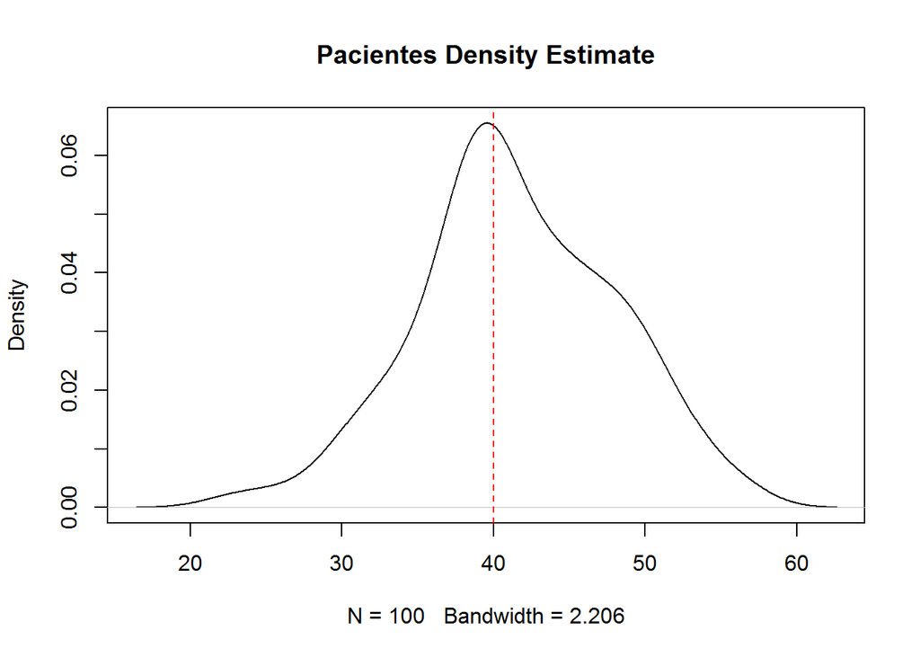

```r
vieram<-function(n){
  k<-sum(n)
  return(k)
}

#############

atrasados<-function(ATRASO){
  ATRASADOS<-ATRASO[ATRASO>0]
  ATRASADOS<-length(ATRASADOS)
  return(ATRASADOS)
}
#ATRASADOS<-atrasados(ATRASO)


#############

tempo.medio<-function(ATRASO,ATRASADOS){
  return(sum(ATRASO)/ATRASADOS)
}

#############

tempo.encerramento<-function(FINAL){
  h<-9+FINAL[MAIOR(FINAL[1],FINAL[2])]/60
  H<-trunc(h,prec=0)
  if(H<16){
    H<-16
    h<-16
  }
  return(h)
}
###########################
v<-c()
a<-c()
A<-c()
t.m<-c()
t.e<-c()

###########################
for(t in 1:100){
  N<-rpois(84,((1/10)*(5)) )
  FILA<-c()
  for ( i in 1:length(N)){
    if(N[i]>0){
      for(j in 1:N[i]){
        FILA<-c(FILA,5*i)
      }
    }
  }
  A<-SIMULING(FILA)
  ATENDIMENTO<-A[1:length(FILA)]
  ATENDIMENTO<-matrix(ATENDIMENTO,ncol=1,byrow=TRUE)
  fila<-matrix(FILA,nco=1,byrow=TRUE)
  ATRASO<-ATENDIMENTO-fila
  MATRIX<-A[(1+length(FILA)):(length(A)-2)]
  FINAL<-A[(length(A)-1):(length(A))]
  rm(FILA)
  MATRIX<-matrix(MATRIX,ncol=2,byrow=TRUE)
  rm(A)


  #v<-c(v,vieram(N))
  v[t]<-vieram(N)
  #a<-c(a,atrasados(ATRASO))
  a[t]<-atrasados(ATRASO)
  #t.m<-c(t.m,tempo.medio(ATRASO,ATRASADOS))
  t.m[t]<-tempo.medio(ATRASO,ATRASADOS)
  #t.e<-c(t.e,tempo.encerramento(FINAL))
  t.e[t]<-tempo.encerramento(FINAL)
}

V<-median(v)
A<-median(a)
T.M<-median(t.m)
T.E<-median(t.e)


v.dist <- density(v)

plot(v.dist,
    main = "Pacientes Density Estimate")
abline(v = V, col=2 , lty="dashed")
```

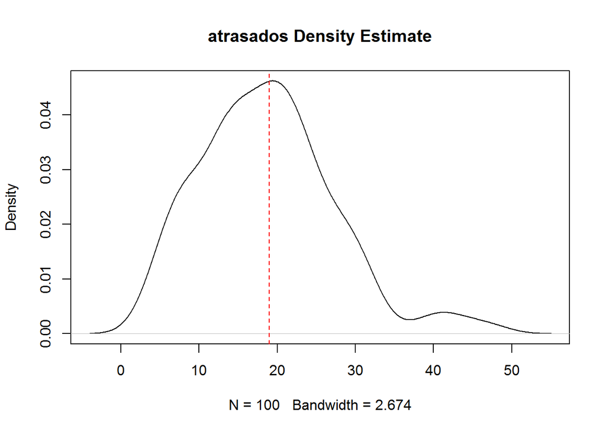

```r
#abline(v = c(quantile(v.dist, probs = c(0.025, 0.975))),
  #    col = "blue", lty = "dashed")
#quantile(v.dist,prob=0.025,na.rm=TRUE)

a.dist <- density(a)

plot(a.dist,
    main = "atrasados Density Estimate")
abline(v = A, col=2 , lty="dashed")
```

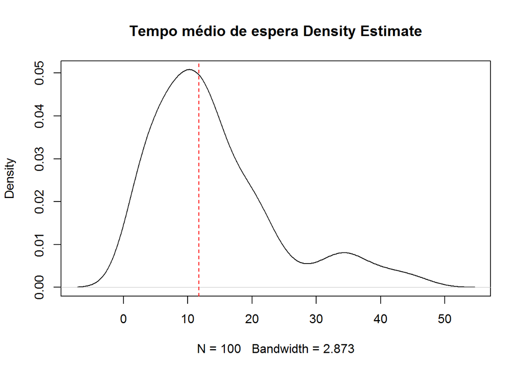

```r
t.m.dist <- density(t.m)

plot(t.m.dist,
    main = "Tempo médio de espera Density Estimate")
abline(v = T.M, col=2 , lty="dashed")
```

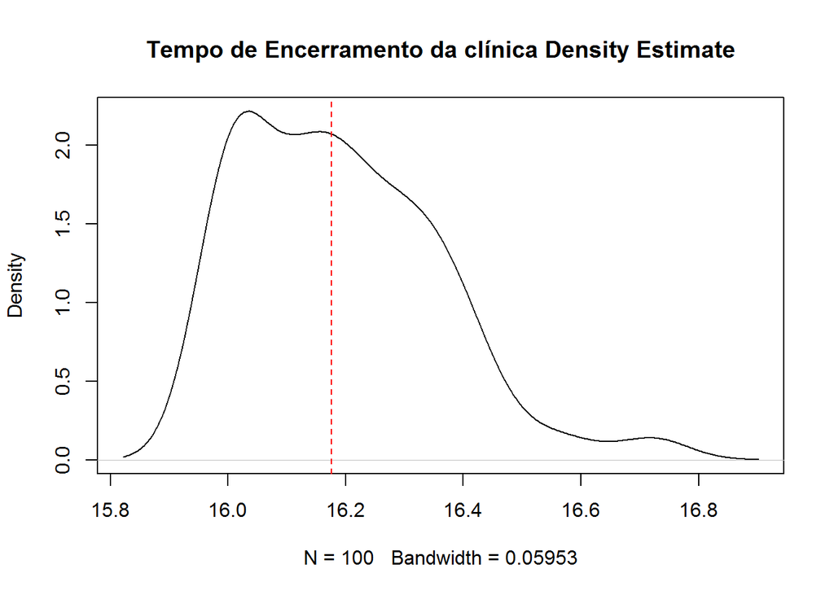

```r
t.e.dist <- density(t.e)

plot(t.e.dist,
    main = "Tempo de Encerramento da clínica Density Estimate")
abline(v = T.E, col=2 , lty="dashed")
```

```r
confidence<-function(X){
  min<-mean(X)
  max<-mean(X)
  s<-sd(X)
  t<-qt(0.975,100-1)
  min<-min-(t*s/sqrt(100))
  max<-max+(t*s/sqrt(100))
  INTERVAL<-c(min,max)
  return(INTERVAL)
}

v.interval<-confidence(v)
a.interval<-confidence(a)
t.m.interval<-confidence(t.m)
t.e.interval<-confidence(t.e)


#Intervalo de confidência para a quantidade de pacientes
v.interval
```

```
## [1] 40.20683 42.79317
```

```r
#Intervalo de confidência para a quantidade de atrasados
a.interval
```

```
## [1] 16.99579 20.40421
```

```r
#Intervalo de confidência para o tempo médio de espera
t.m.interval
```

```
## [1] 12.03920 15.98253
```

```r
#Intervalo de confidência para o tempo de encerramento.
t.e.interval
```

```
## [1] 16.15848 16.22442
```

## Referências

https://web.stanford.edu/class/bios221/labs/simulation/Lab_3_simulation.html

https://www.cyclismo.org/tutorial/R/confidence.html

https://en.wikipedia.org/wiki/Confidence_interval